# Week 2: Data Pre-Processing and Exploration

## Theory and Practice

Ying Lin, Ph.D | ylin65@syr.edu

24 January, 2020

## Outline of the Topics

- A standard machine learning pipeline
- Dataset types, attribute types and conversion
- Data quality issues and cleaning/transformation/preprocessing
- Exploratory data analysis and visualization
- R/Python demo

## A Standard Machine Learning Pipeline

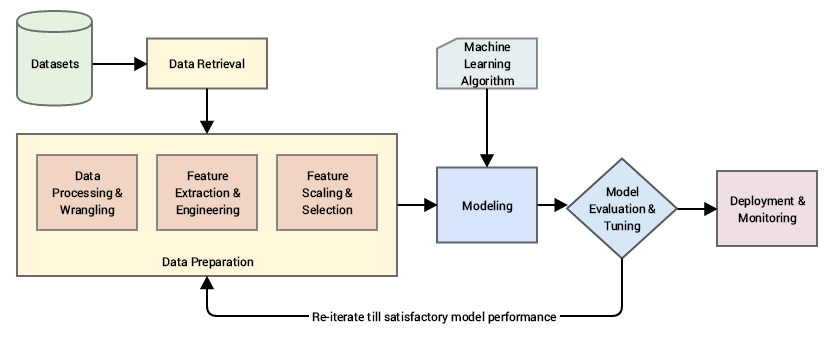

## Dataset Types

- Structured data: Record dataset
  - Row: object, record, example
  - Column: feature, attribute, variable
- Unstructured data
  - Market basket data
  - Text data
  - Image data
  - Sequence data

## Attribute Types

- Categorical (Qualitative)
  - Nominal: e.g. name, zip code
  - Ordinal: e.g. rating, rank
- Numerical (Quantitative)
  - Interval: e.g. IQ, temperature in fahrenheit, date
  - Ratio: e.g. height, weight
- Properties of Attributes
  - Distinctness
  - Order
  - Substraction
  - Division

## Discretization

- Discrete vs. continuous
- Discretization: one type of data transformation from a continuous attribute to a discrete one
  - Equal interval
  - Equal frequency
  - K-means
  - Equal entropy
- Some data mining and machine learning algorithms don’t work with continuous attributes: decision tree induction, association rule mining, naive Bayes classifier

## Numerization

- Label/integer encoding: assume ordinal property of the categorical attributes
- One-hot encoding: create the same number of dummy variables/binary attributes for the categorical attributes with the same number of possible values (minus one), i.e. dummify
- Target encoding: use the target attribute (categorical and numerical) to encode. Careful with overfitting.
- Frequency encoding
- Embedding
- When needed: regression, PCA, distance-based methods (KNN, clustering analysis), nueral network, SVM

## Data Quality Issues

- Data noise vs. outliers
  - Risk of overfitting
- Missing values
  - Can’t be tolerated by neural network, linear/logistic regression, etc.
- Duplicate data
- Multicollinearity
- Attributes with low to no variance
- Imbalanced dataset

## Data Transformation

- Transformation based on rows (records, objects)
- Transformation based on columns (attributes, features)
- Aggregation and data roll-up
- Attribute transformation/feature engineering
- Sampling: e.g. bootstrap resampling
- Dimension reduction:
  - Principal Component Analysis (PCA): represent data in lower dimension and address multicollinearity
  - Remove attributes with low to no variance

## Aggregation

- Combine multiple attributes (or objects) into a single attribute (or object)
- Benefits
  - Data reduction
  - Reduce data variability
  - Change of analysis scale
  - Generate summary/descriptive analysis

## Feature Engineering and Attribute Transformation

- Discretization and numerization
  - Many ML algorithms can only work with categorical or numerical attributes
- Apply transformation function, such as $\log(x)$, $e^x$, $x^k$, $\frac{1}{x}$
  - Reduce effects of outliers
- [Normalization and standardization (scale and center)](https://sebastianraschka.com/Articles/2014_about_feature_scaling.html)
- Algorithms that require both numerization and normalization
  - Distance-based algorithms: KNN, Cluster Analysis, kernel based methods such as SVM
  - Neural network and deep learning
  - PCA

## Normalization and Standardization

- Z-score transformation: convert numerical values into the distance in standard deviation units form the mean.
  $$z_i = \frac{x_i - \overline{x}}{\sigma}$$
- Min-Max standardization: Standardize the range of all the numerical attributes to [0, 1]

$$f(x) = \frac{x - min}{max - min}$$

## Sampling

- Create *representative* data samples with the similar properties as the original distribution
  - Sampling with vs. without replacement
  - Sample size
- Sampling Methods
  - Convenience sampling
  - Random sampling
  - Stratified sampling
  - Systematic sampling

## Exploratory Data Analysis (EDA)

- EDA is an iterative cycle
  - Generate questions/hypotheses about your data
  - Search for answers by cleaning, visualising, transforming and modeling your data
  - Use what you learn to refine your questions and generate new questions
- EDA is a state of minds: curiosity and inquisitiveness
  - EDA is fundamentally a creative process that is shaped by a series of Q & A
  - Key to asking *quality* questions is to generate a large *quantity* of questions followed up with data checking and exploration

## Visualization

- Multivariate analysis to intuitively recognize higher-dimensional data patterns and derive insights to guide data modeling
- Increase expressiveness through integrating more and various type of attributes
- Common visualization techniques and their variants
  - Basic types: histogram, box plot, bar chart, scatter plot, bubble chart, pie/donut pie chart, area graph, density plot, heatmap, etc.
  - Special types: word cloud, tree diagram, network diagram, radar chart, sankey diagram, etc.
  - Combination: faceted plot, dashboarding

## Demo Dataset: Car MPG Dataset

```r
library(ggplot2)
data(mpg, package = "ggplot2")
dim(mpg)
```

```
## [1] 234  11
```

```r
str(mpg)
```

```
## Classes 'tbl_df', 'tbl' and 'data.frame':    234 obs. of  11 variables:
##  $ manufacturer: chr  "audi" "audi" "audi" "audi" ...
##  $ model       : chr  "a4" "a4" "a4" "a4" ...
##  $ displ       : num  1.8 1.8 2 2 2.8 2.8 3.1 1.8 1.8 2 ...
##  $ year        : int  1999 1999 2008 2008 1999 1999 2008 1999 1999 2008 ...
##  $ cyl         : int  4 4 4 4 6 6 6 4 4 4 ...
##  $ trans       : chr  "auto(l5)" "manual(m5)" "manual(m6)" "auto(av)" ...
##  $ drv         : chr  "f" "f" "f" "f" ...
##  $ cty         : int  18 21 20 21 16 18 18 18 16 20 ...
##  $ hwy         : int  29 29 31 30 26 26 27 26 25 28 ...
##  $ fl          : chr  "p" "p" "p" "p" ...
##  $ class       : chr  "compact" "compact" "compact" "compact" ...
```

## A Preview of Data

```r
knitr::kable(mpg)
```

| manufacturer | model | displ | year | cyl | trans | drv | cty | hwy | fl | class |
| --- | --- | --- | --- | --- | --- | --- | --- | --- | --- | --- |
| audi | a4 | 1.8 | 1999 | 4 | auto(l5) | f | 18 | 29 | p | compact |
| audi | a4 | 1.8 | 1999 | 4 | manual(m5) | f | 21 | 29 | p | compact |
| audi | a4 | 2.0 | 2008 | 4 | manual(m6) | f | 20 | 31 | p | compact |
| audi | a4 | 2.0 | 2008 | 4 | auto(av) | f | 21 | 30 | p | compact |
| audi | a4 | 2.8 | 1999 | 6 | auto(l5) | f | 16 | 26 | p | compact |
| audi | a4 | 2.8 | 1999 | 6 | manual(m5) | f | 18 | 26 | p | compact |
| audi | a4 | 3.1 | 2008 | 6 | auto(av) | f | 18 | 27 | p | compact |
| audi | a4 quattro | 1.8 | 1999 | 4 | manual(m5) | 4 | 18 | 26 | p | compact |
| audi | a4 quattro | 1.8 | 1999 | 4 | auto(l5) | 4 | 16 | 25 | p | compact |
| audi | a4 quattro | 2.0 | 2008 | 4 | manual(m6) | 4 | 20 | 28 | p | compact |
| audi | a4 quattro | 2.0 | 2008 | 4 | auto(s6) | 4 | 19 | 27 | p | compact |
| audi | a4 quattro | 2.8 | 1999 | 6 | auto(l5) | 4 | 15 | 25 | p | compact |
| audi | a4 quattro | 2.8 | 1999 | 6 | manual(m5) | 4 | 17 | 25 | p | compact |
| audi | a4 quattro | 3.1 | 2008 | 6 | auto(s6) | 4 | 17 | 25 | p | compact |
| audi | a4 quattro | 3.1 | 2008 | 6 | manual(m6) | 4 | 15 | 25 | p | compact |
| audi | a6 quattro | 2.8 | 1999 | 6 | auto(l5) | 4 | 15 | 24 | p | midsize |
| audi | a6 quattro | 3.1 | 2008 | 6 | auto(s6) | 4 | 17 | 25 | p | midsize |
| audi | a6 quattro | 4.2 | 2008 | 8 | auto(s6) | 4 | 16 | 23 | p | midsize |
| chevrolet | c1500 suburban 2wd | 5.3 | 2008 | 8 | auto(l4) | r | 14 | 20 | r | suv |
| chevrolet | c1500 suburban 2wd | 5.3 | 2008 | 8 | auto(l4) | r | 11 | 15 | e | suv |
| chevrolet | c1500 suburban 2wd | 5.3 | 2008 | 8 | auto(l4) | r | 14 | 20 | r | suv |
| chevrolet | c1500 suburban 2wd | 5.7 | 1999 | 8 | auto(l4) | r | 13 | 17 | r | suv |
| chevrolet | c1500 suburban 2wd | 6.0 | 2008 | 8 | auto(l4) | r | 12 | 17 | r | suv |
| chevrolet | corvette | 5.7 | 1999 | 8 | manual(m6) | r | 16 | 26 | p | 2seater |
| chevrolet | corvette | 5.7 | 1999 | 8 | auto(l4) | r | 15 | 23 | p | 2seater |
| chevrolet | corvette | 6.2 | 2008 | 8 | manual(m6) | r | 16 | 26 | p | 2seater |
| chevrolet | corvette | 6.2 | 2008 | 8 | auto(s6) | r | 15 | 25 | p | 2seater |
| chevrolet | corvette | 7.0 | 2008 | 8 | manual(m6) | r | 15 | 24 | p | 2seater |
| chevrolet | k1500 tahoe 4wd | 5.3 | 2008 | 8 | auto(l4) | 4 | 14 | 19 | r | suv |
| chevrolet | k1500 tahoe 4wd | 5.3 | 2008 | 8 | auto(l4) | 4 | 11 | 14 | e | suv |

[output cut: 204 more lines]

## Meta Data of “mpg” Data frame (1)

| Variable | Description |
| --- | --- |
| manufacturer | carmarker |
| model | model name |
| displ | engine displacement (in litres) |
| year | year of manufacture |
| cyl | number of cylinders |
| trans | type of transmission |
| drv | f = front-wheel drive, r = rear wheel drive, 4 = 4wd |
| cty | city miles per gallon |
| hwy | highway miles per gallon |
| fl | fuel type |
| class | “type” of car |

## Change Attribute Type

```r
char_var <- sapply(mpg, is.character)
mpg[, char_var] <- lapply(mpg[, char_var], as.factor)
str(mpg)
```

```
## Classes 'tbl_df', 'tbl' and 'data.frame':    234 obs. of  11 variables:
##  $ manufacturer: Factor w/ 15 levels "audi","chevrolet",..: 1 1 1 1 1 1 1 1 1 1 ...
##  $ model       : Factor w/ 38 levels "4runner 4wd",..: 2 2 2 2 2 2 2 3 3 3 ...
##  $ displ       : num  1.8 1.8 2 2 2.8 2.8 3.1 1.8 1.8 2 ...
##  $ year        : int  1999 1999 2008 2008 1999 1999 2008 1999 1999 2008 ...
##  $ cyl         : int  4 4 4 4 6 6 6 4 4 4 ...
##  $ trans       : Factor w/ 10 levels "auto(av)","auto(l3)",..: 4 9 10 1 4 9 1 9 4 10 ...
##  $ drv         : Factor w/ 3 levels "4","f","r": 2 2 2 2 2 2 2 1 1 1 ...
##  $ cty         : int  18 21 20 21 16 18 18 18 16 20 ...
##  $ hwy         : int  29 29 31 30 26 26 27 26 25 28 ...
##  $ fl          : Factor w/ 5 levels "c","d","e","p",..: 4 4 4 4 4 4 4 4 4 4 ...
##  $ class       : Factor w/ 7 levels "2seater","compact",..: 2 2 2 2 2 2 2 2 2 2 ...
```

## Illustration of EDA

Descriptive data analysis to identify interesting data patterns; e.g. compare fuel economy of different car classes

```r
library(dplyr)
mpg %>% group_by(class) %>%
  summarise(ct=n(), cty=round(mean(cty, na.rm=T), 1),
            hwy=round(mean(hwy, na.rm=T), 1),
            displ=round(mean(displ, na.rm=T), 1)) %>%
  arrange(desc(cty))
```

```
## # A tibble: 7 x 5
##   class         ct   cty   hwy displ
##   <fct>      <int> <dbl> <dbl> <dbl>
## 1 subcompact    35  20.4  28.1   2.7
## 2 compact       47  20.1  28.3   2.3
## 3 midsize       41  18.8  27.3   2.9
## 4 minivan       11  15.8  22.4   3.4
## 5 2seater        5  15.4  24.8   6.2
## 6 suv           62  13.5  18.1   4.5
## 7 pickup        33  13    16.9   4.4
```

## Discretization: Conversion from Numerical to Categorical Attributes

```r
library(dplyr)
library(arules)
mpg$displ_grp <- arules::discretize(mpg$displ, method = "frequency",
                            breaks = 3, labels = c("low",
                                                   "medium", "high"))
mpg %>%
  group_by(displ_grp) %>%
  summarise(avg_displ = mean(displ), count = n(), min = min(displ), max = max(displ))
```

```
## # A tibble: 3 x 5
##   displ_grp avg_displ count   min   max
##   <fct>         <dbl> <int> <dbl> <dbl>
## 1 low            2.02    62   1.6   2.4
## 2 medium         3.06    86   2.5   3.9
## 3 high           4.93    86   4     7
```

## Convert from Categorical to Numerical Attributes

```r
library()
unique(mpg$drv)
```

```
## [1] f 4 r
## Levels: 4 f r
```

```r
dmy <- caret::dummyVars(" ~ drv", data = mpg, fullRank = T)
head(data.frame(predict(dmy, newdata = mpg)), 5)
```

```
##   drv.f drv.r
## 1     1     0
## 2     1     0
## 3     1     0
## 4     1     0
## 5     1     0
```

## Dimension Reduction and Feature Engineering: PCA

```r
trans = caret::preProcess(mpg[, sapply(mpg, is.numeric)], method=c("center", "scale", "pca"),
                   pcaComp = 5)
PC = predict(trans, mpg[, sapply(mpg, is.numeric)])
head(PC, 5)
```

```
##          PC1        PC2        PC3         PC4         PC5
## 1 -1.8858984  0.9723721 -0.4244892 -0.18149906 -0.52192770
## 2 -2.2424056  0.9025047 -0.1179838 -0.07438406 -0.01253529
## 3 -2.0917184 -1.0910392 -0.3338737 -0.07819127 -0.37494694
## 4 -2.1275729 -1.0902013 -0.3212256 -0.01996586 -0.09463483
## 5 -0.3953825  0.9725482  0.1057113 -0.48523023 -0.38418629
```

```r
str(PC)
```

```
## 'data.frame':    234 obs. of  5 variables:
##  $ PC1: num  -1.886 -2.242 -2.092 -2.128 -0.395 ...
##  $ PC2: num  0.972 0.903 -1.091 -1.09 0.973 ...
##  $ PC3: num  -0.424 -0.118 -0.334 -0.321 0.106 ...
##  $ PC4: num  -0.1815 -0.0744 -0.0782 -0.02 -0.4852 ...
##  $ PC5: num  -0.5219 -0.0125 -0.3749 -0.0946 -0.3842 ...
```

## Remove Features with No or Low Variances

```r
nzv <- caret::nearZeroVar(mpg[mpg$year == 1999, ], saveMetrics = T)
colnames(mpg)[nzv$nzv]
```

```
## [1] "year"
```

```r
nzv[nzv$nzv, ]
```

```
##      freqRatio percentUnique zeroVar  nzv
## year         0     0.8547009    TRUE TRUE
```